# CASA0005 Week 03 Homework：澳大利亚城市未来最高气温

ACCESS-CM2，SSP1-2.6 与 SSP5-8.5，2081–2100

比较澳大利亚 15 个固定城市样本在 SSP1-2.6 与 SSP5-8.5 下的未来最高气温，模型为 ACCESS-CM2，分辨率为 5 arc-minutes，时期为 2081–2100。差值统一为 **SSP585 − SSP126**。

`tmax` 是每日最高气温的月平均气候值；十二层对应十二个日历月，不是二十年的逐年值或绝对最高温纪录。两条路径分别为 SSP1 / SSP5 家族内的具体情景。两情景固定模型、时期、网格、城市集合和取样格号。

项目为课程 `casa0005.Rproj`。Knit 从头计算普通分析块；安装、下载和导出独立执行。

## 结果摘要

180 个城市×月份配对均完整。SSP585−SSP126 的城市月份等权平均差为 3.31 °C；城市平均差从 Bunbury 的 2.78 °C 到 Orange 的 3.88 °C。三个海岸邻格均在 15 km 内；结果是单一模型、有限城市的情景比较。

## 环境

```r
helper <- c("tutorial-tools.R", "../tutorial-tools.R") # 同时适配从课程根目录和 week03 目录打开文件
helper <- helper[file.exists(helper)] # 只保留实际存在的工具文件路径
if (!length(helper)) stop("先打开课程 casa0005.Rproj，再打开 week03/homework.Rmd。", call. = FALSE) # 路径不对时给出明确提示
source(helper[[1]]) # 读取共用路径、包检查和连接键检查函数
root <- gis_root()
local_lib <- file.path(root, ".local-review", "R-library") # 指定课程已有的本地 R 包库
if (dir.exists(local_lib)) .libPaths(c(local_lib, .libPaths())) # 若已有本地包库，把它放在查找顺序前面
required_packages <- c("sf", "terra", "tidyverse", "tmap", "ragg") # 列出本文件要用的包
missing_packages <- required_packages[!vapply(required_packages, requireNamespace, logical(1), quietly = TRUE)] # 检查哪些包尚未安装
print(root)
```

```
## [1] "[project]"
```

```r
print(missing_packages)
```

```
## character(0)
```

### 依赖安装（缺包时）

课程本地包库为 `.local-review/R-library`，不纳入源代码提交。

```r
dir.create(local_lib, recursive = TRUE, showWarnings = FALSE) # 创建课程本地包库；已有目录时保留原内容
.libPaths(c(local_lib, .libPaths())) # 让当前 R 会话能找到这个包库
options(timeout = max(1200, getOption("timeout", 60))) # 给较大的包至少 1200 秒下载时间
if (length(missing_packages)) install.packages(missing_packages, lib = local_lib, repos = "https://cloud.r-project.org") # 只安装缺少的包
```

### 加载依赖

```r
gis_packages(required_packages) # 缺包时停止，避免直到后面的函数才报错
library(sf) # 处理带 CRS 的国家边界和城市点
library(terra) # 读取、裁剪、遮罩和提取栅格
library(tidyverse)
library(tmap) # 使用 tmap 4 绘制空间结果图
stopifnot(packageVersion("tmap") >= "4.0.0", packageVersion("dplyr") >= "1.1.1") # 检查本教程使用的 API 版本
```

## 输入文件

国界复用 GADM 4.1 Australia；未来气温采用 WorldClim CMIP6 的 ACCESS-CM2、5 分、2081–2100 `tmax`。课堂历史 `tavg` 不替代未来最高气温。输入清单记录 URL、完整字节数和本地路径。

```r
gadm_file <- file.path(root, "data/raw/week03/gadm41_AUS.gpkg") # 复用课堂的 GADM 4.1 澳大利亚边界
raw_dir <- file.path(root, "data/raw/week03/homework/ACCESS-CM2-5m-tmax-2081-2100") # 给本作业的未来温度单独建目录
dir.create(raw_dir, recursive = TRUE, showWarnings = FALSE) # 创建目录，不删除或覆盖旧文件
input_manifest <- tibble::tibble( # 用一张小表保存情景、真实文件名和核验大小
  scenario = c("SSP126", "SSP585"), # 两行分别代表两个情景
  filename = c("wc2.1_5m_tmax_ACCESS-CM2_ssp126_2081-2100.tif", "wc2.1_5m_tmax_ACCESS-CM2_ssp585_2081-2100.tif"), # 保留官方下载文件名
  expected_bytes = c(67905178, 68183485) # 2026-11-01 官方服务器报告的完整文件大小
)
input_manifest <- input_manifest %>% dplyr::mutate( # 在清单中加入可直接下载的 URL 和本地位置
  url = paste0("https://geodata.ucdavis.edu/cmip6/5m/ACCESS-CM2/", tolower(scenario), "/", filename), # 拼接官方服务器路径
  path = file.path(raw_dir, filename) # 将文件名放到本作业 raw 目录
)
print(input_manifest, width = Inf) # 把完整路径和 URL 展开显示，下载前核对
```

```
## # A tibble: 2 × 5
##   scenario filename                                      expected_bytes
##   <chr>    <chr>                                                  <dbl>
## 1 SSP126   wc2.1_5m_tmax_ACCESS-CM2_ssp126_2081-2100.tif       67905178
## 2 SSP585   wc2.1_5m_tmax_ACCESS-CM2_ssp585_2081-2100.tif       68183485
##   url
##   <chr>
## 1 https://geodata.ucdavis.edu/cmip6/5m/ACCESS-CM2/ssp126/wc2.1_5m_tmax_ACCESS-C…
## 2 https://geodata.ucdavis.edu/cmip6/5m/ACCESS-CM2/ssp585/wc2.1_5m_tmax_ACCESS-C…
##   path
##   <chr>
## 1 /Users/aries/Documents/GitHub/casa/05-geographic-information-systems-and-scie…
## 2 /Users/aries/Documents/GitHub/casa/05-geographic-information-systems-and-scie…
```

### 下载与完整性

已有完整文件复用；新下载先写 `.part`，通过大小核验后才成为正式输入，不覆盖已有不同版本。若官方版本改变，先更新来源记录与清单。

```r
download_once <- function(url, target, expected_bytes) { # 定义一次性下载函数；已有完整文件不覆盖
  if (file.exists(target)) { # 先检查正式文件是否已经存在
    if (!isTRUE(file.info(target)$size == expected_bytes)) stop("已有文件大小不符，请保留后核查：", target) # 不覆盖不完整或不同版本的文件
    message("复用完整文件：", target) # 记录复用状态
    return(invisible(target)) # 返回已有路径并结束本次函数调用
  }
  dir.create(dirname(target), recursive = TRUE, showWarnings = FALSE) # 确保目标的上层目录存在
  part <- tempfile(pattern = "download-", tmpdir = dirname(target), fileext = ".part") # 临时文件不冒充正式 TIFF 或 GeoPackage
  on.exit(if (file.exists(part)) unlink(part), add = TRUE) # 函数结束时只清理本次建立的临时文件
  old_options <- options(timeout = max(1200, getOption("timeout", 60))) # 临时延长下载超时
  on.exit(options(old_options), add = TRUE) # 无论成功或失败，结束后恢复原下载设置
  status <- utils::download.file(url, destfile = part, method = "libcurl", mode = "wb", quiet = FALSE) # 二进制下载并显示进度
  if (!isTRUE(status == 0L)) stop("下载失败，请检查网络后重试：", url) # 非成功状态不能继续改名
  if (!isTRUE(file.info(part)$size == expected_bytes)) stop("下载大小不完整或官方版本已变化：", url) # 对比完整字节数
  if (file.exists(target)) stop("目标文件在下载期间出现，已停止以免覆盖：", target) # 再检查一次同名文件
  if (!file.rename(part, target)) stop("临时文件改名失败：", target) # 只有完整下载才成为正式输入
  message("下载完成：", target) # 显示最终保存位置
  invisible(target) # 返回路径，不把整个文件读进 R
}
if (!file.exists(gadm_file)) download_once("https://geodata.ucdavis.edu/gadm/gadm4.1/gpkg/gadm41_AUS.gpkg", gadm_file, 91648000) # 缺少边界时才补下载约 92 MB 的课堂边界
for (i in seq_len(nrow(input_manifest))) { # 按清单顺序下载两种情景
  download_once(input_manifest$url[[i]], input_manifest$path[[i]], input_manifest$expected_bytes[[i]]) # 每次只处理一个输入文件
}
```

### 本地输入记录

保存实际文件大小与 MD5；摘要用于识别输入版本，不能单独证明来源或分析正确性。

```r
if (!file.exists(gadm_file)) stop("缺少澳大利亚边界，请完成第 2.2 步。") # 明确指出缺少哪个前置输入
if (!all(file.exists(input_manifest$path))) stop("两份未来 tmax 尚未齐全，请完成第 2.2 步。") # 防止把课堂历史温度当成替代输入
actual_bytes <- unname(file.info(input_manifest$path)$size) # 读取本地两份文件的字节数
if (!identical(as.numeric(actual_bytes), as.numeric(input_manifest$expected_bytes))) stop("未来温度文件大小与清单不符，请核对下载。") # 检查本地下载完整性
tmax126_file <- input_manifest$path[input_manifest$scenario == "SSP126"] # 取得低排放情景的本地路径
tmax585_file <- input_manifest$path[input_manifest$scenario == "SSP585"] # 取得高排放情景的本地路径
input_record <- input_manifest %>% dplyr::mutate(bytes_on_disk = actual_bytes, md5 = unname(tools::md5sum(path))) # 记录当前输入的大小和校验值，复现记录
print(input_record, width = Inf)
```

```
## # A tibble: 2 × 7
##   scenario filename                                      expected_bytes
##   <chr>    <chr>                                                  <dbl>
## 1 SSP126   wc2.1_5m_tmax_ACCESS-CM2_ssp126_2081-2100.tif       67905178
## 2 SSP585   wc2.1_5m_tmax_ACCESS-CM2_ssp585_2081-2100.tif       68183485
##   url
##   <chr>
## 1 https://geodata.ucdavis.edu/cmip6/5m/ACCESS-CM2/ssp126/wc2.1_5m_tmax_ACCESS-C…
## 2 https://geodata.ucdavis.edu/cmip6/5m/ACCESS-CM2/ssp585/wc2.1_5m_tmax_ACCESS-C…
##   path
##   <chr>
## 1 /Users/aries/Documents/GitHub/casa/05-geographic-information-systems-and-scie…
## 2 /Users/aries/Documents/GitHub/casa/05-geographic-information-systems-and-scie…
##   bytes_on_disk md5
##           <dbl> <chr>
## 1      67905178 07fe64fc80688b7799d2838e2e3d0833
## 2      68183485 3561b01c565d0dd7af2707ba1b9228f6
```

## 国界与坐标参考系

国家层为 ADM_0；EPSG:3112 用于澳大利亚显示。坐标转换使用 `st_transform()`，不以改写 CRS 标签代替转换。离岸岛屿保留在分析范围内。

```r
country_layers <- sf::st_layers(gadm_file) # 查看 GeoPackage 内有哪些行政层
print(country_layers)
```

```
## Driver: GPKG
## Available layers:
##   layer_name geometry_type features fields crs_name
## 1  ADM_ADM_0 Multi Polygon        1      2   WGS 84
## 2  ADM_ADM_1 Multi Polygon       11     11   WGS 84
## 3  ADM_ADM_2 Multi Polygon      568     13   WGS 84
```

```r
country_layer <- country_layers$name[grepl("_0$", country_layers$name)] # 选择国家级别 ADM_0，不拿州或县代替国家
if (length(country_layer) != 1L) stop("国家层不唯一，请核对 GADM 图层列表。") # 不在多份候选中随意挑选
aus <- sf::st_read(gadm_file, layer = country_layer, quiet = TRUE) # 读取原始澳大利亚国界
print(sf::st_crs(aus)) # 查看原始坐标参考系
```

```
## Coordinate Reference System:
##   User input: WGS 84
##   wkt:
## GEOGCRS["WGS 84",
##     ENSEMBLE["World Geodetic System 1984 ensemble",
##         MEMBER["World Geodetic System 1984 (Transit)"],
##         MEMBER["World Geodetic System 1984 (G730)"],
##         MEMBER["World Geodetic System 1984 (G873)"],
##         MEMBER["World Geodetic System 1984 (G1150)"],
##         MEMBER["World Geodetic System 1984 (G1674)"],
##         MEMBER["World Geodetic System 1984 (G1762)"],
##         MEMBER["World Geodetic System 1984 (G2139)"],
##         MEMBER["World Geodetic System 1984 (G2296)"],
##         ELLIPSOID["WGS 84",6378137,298.257223563,
##             LENGTHUNIT["metre",1]],
##         ENSEMBLEACCURACY[2.0]],
##     PRIMEM["Greenwich",0,
##         ANGLEUNIT["degree",0.0174532925199433]],
##     CS[ellipsoidal,2],
##         AXIS["geodetic latitude (Lat)",north,
##             ORDER[1],
##             ANGLEUNIT["degree",0.0174532925199433]],
##         AXIS["geodetic longitude (Lon)",east,
##             ORDER[2],
##             ANGLEUNIT["degree",0.0174532925199433]],
##     USAGE[
##         SCOPE["Horizontal component of 3D system."],
##         AREA["World."],
##         BBOX[-90,-180,90,180]],
##     ID["EPSG",4326]]
```

```r
if (is.na(sf::st_crs(aus))) stop("边界缺少 CRS，先核对原始文件，不能猜坐标系。") # 没有 CRS 时停止
aus_3112 <- sf::st_transform(aus, 3112) # 转成澳大利亚 Lambert 投影，供制图使用
print(sf::st_crs(aus_3112)) # 查看转换后的米制 CRS
```

```
## Coordinate Reference System:
##   User input: EPSG:3112
##   wkt:
## PROJCRS["GDA94 / Geoscience Australia Lambert",
##     BASEGEOGCRS["GDA94",
##         DATUM["Geocentric Datum of Australia 1994",
##             ELLIPSOID["GRS 1980",6378137,298.257222101,
##                 LENGTHUNIT["metre",1]]],
##         PRIMEM["Greenwich",0,
##             ANGLEUNIT["degree",0.0174532925199433]],
##         ID["EPSG",4283]],
##     CONVERSION["Geoscience Australia Standard National Scale Lambert Projection",
##         METHOD["Lambert Conic Conformal (2SP)",
##             ID["EPSG",9802]],
##         PARAMETER["Latitude of false origin",0,
##             ANGLEUNIT["degree",0.0174532925199433],
##             ID["EPSG",8821]],
##         PARAMETER["Longitude of false origin",134,
##             ANGLEUNIT["degree",0.0174532925199433],
##             ID["EPSG",8822]],
##         PARAMETER["Latitude of 1st standard parallel",-18,
##             ANGLEUNIT["degree",0.0174532925199433],
##             ID["EPSG",8823]],
##         PARAMETER["Latitude of 2nd standard parallel",-36,
##             ANGLEUNIT["degree",0.0174532925199433],
##             ID["EPSG",8824]],
##         PARAMETER["Easting at false origin",0,
##             LENGTHUNIT["metre",1],
##             ID["EPSG",8826]],
##         PARAMETER["Northing at false origin",0,
##             LENGTHUNIT["metre",1],
##             ID["EPSG",8827]]],
##     CS[Cartesian,2],
##         AXIS["(E)",east,
##             ORDER[1],
##             LENGTHUNIT["metre",1]],
##         AXIS["(N)",north,
##             ORDER[2],
##             LENGTHUNIT["metre",1]],
##     USAGE[
##         SCOPE["Topographic mapping, environmental studies."],
##         AREA["Australia - Australian Capital Territory; New South Wales; Northern Territory; Queensland; South Australia; Tasmania; Western Australia; Victoria."],
##         BBOX[-43.7,112.85,-9.86,153.69]],
##     ID["EPSG",3112]]
```

## 月份、网格与温度单位

核对十二层 `tmax01`–`tmax12`、5/60 度分辨率、CRS 和共同网格后，月份命名为 Jan–Dec。本次 CMIP6 浮点 TIFF 已为 °C，不套用旧版 `°C×10` 规则，不再除以 10。

```r
tmax126 <- terra::rast(tmax126_file) # 读取 SSP126 的 GeoTIFF，先建立栅格对象
tmax585 <- terra::rast(tmax585_file) # 读取 SSP585 的 GeoTIFF
print(tmax126) # 查看尺寸、范围、分辨率、CRS 与波段
```

```
## class       : SpatRaster
## size        : 2160, 4320, 12  (nrow, ncol, nlyr)
## resolution  : 0.08333333, 0.08333333  (x, y)
## extent      : -180, 180, -90, 90  (xmin, xmax, ymin, ymax)
## coord. ref. : lon/lat WGS 84 (EPSG:4326)
## source      : wc2.1_5m_tmax_ACCESS-CM2_ssp126_2081-2100.tif
## names       :     tmax01,     tmax02,     tmax03,    tmax04,     tmax05,    tmax06, ...
## min values  : -38.099998, -37.099998, -50.900002,     -55.5, -56.599998,       -57, ...
## max values  :  44.799999,  42.799999,  44.299999, 46.200001,  47.900002, 50.299999, ...
```

```r
print(tmax585) # 对另一个情景做相同检查
```

```
## class       : SpatRaster
## size        : 2160, 4320, 12  (nrow, ncol, nlyr)
## resolution  : 0.08333333, 0.08333333  (x, y)
## extent      : -180, 180, -90, 90  (xmin, xmax, ymin, ymax)
## coord. ref. : lon/lat WGS 84 (EPSG:4326)
## source      : wc2.1_5m_tmax_ACCESS-CM2_ssp585_2081-2100.tif
## names       :     tmax01,     tmax02,     tmax03,     tmax04,     tmax05,     tmax06, ...
## min values  : -31.700001, -33.700001, -45.099998, -50.900002, -52.200001, -52.200001, ...
## max values  :       49.5,  48.299999,  47.700001,  50.599998,  52.099998,  53.900002, ...
```

```r
print(names(tmax126)) # 核对原始波段应为 tmax01 到 tmax12
```

```
##  [1] "tmax01" "tmax02" "tmax03" "tmax04" "tmax05" "tmax06" "tmax07" "tmax08"
##  [9] "tmax09" "tmax10" "tmax11" "tmax12"
```

```r
print(names(tmax585)) # 确认另一个情景的月份顺序一致
```

```
##  [1] "tmax01" "tmax02" "tmax03" "tmax04" "tmax05" "tmax06" "tmax07" "tmax08"
##  [9] "tmax09" "tmax10" "tmax11" "tmax12"
```

```r
expected_bands <- sprintf("tmax%02d", 1:12) # 生成 tmax01、tmax02……tmax12 的目标名称
stopifnot(terra::nlyr(tmax126) == 12L, terra::nlyr(tmax585) == 12L) # 两组都必须有 12 个月
stopifnot(identical(names(tmax126), expected_bands), identical(names(tmax585), expected_bands)) # 不在月份不明时擅自改名
stopifnot(all(abs(terra::res(tmax126) - 5 / 60) < 1e-6)) # 检查目标网格为 5 分，即约 0.083333 度
stopifnot(nzchar(terra::crs(tmax126)), nzchar(terra::crs(tmax585))) # 两份栅格都必须有 CRS
stopifnot(terra::compareGeom(tmax126, tmax585, lyrs = TRUE, res = TRUE, stopOnError = FALSE)) # 检查两个情景的层数、CRS、范围、行列和分辨率相同
print(terra::scoff(tmax126))
```

```
##       scale offset
##  [1,]     1      0
##  [2,]     1      0
##  [3,]     1      0
##  [4,]     1      0
##  [5,]     1      0
##  [6,]     1      0
##  [7,]     1      0
##  [8,]     1      0
##  [9,]     1      0
## [10,]     1      0
## [11,]     1      0
## [12,]     1      0
```

```r
print(terra::scoff(tmax585)) # 对另一情景做同样的缩放检查
```

```
##       scale offset
##  [1,]     1      0
##  [2,]     1      0
##  [3,]     1      0
##  [4,]     1      0
##  [5,]     1      0
##  [6,]     1      0
##  [7,]     1      0
##  [8,]     1      0
##  [9,]     1      0
## [10,]     1      0
## [11,]     1      0
## [12,]     1      0
```

```r
names(tmax126) <- month.abb # 已确认月份顺序后，改成 Jan 到 Dec，方便阅读
names(tmax585) <- month.abb # 两个情景使用同一套月份列名
```

## 城市参考点

课堂坐标为起点，Broome 使用南纬 -17.96；Melbourne 改用 BOM Olympic Park 086338 的 `(144.98, -37.83)`，原课堂坐标保存在 `source_lon` / `source_lat`。BOM 只提供参考位置，温度仍来自 WorldClim。十五个地点不是完整城市行政区，也不覆盖全部澳大利亚城市。

```r
cities <- tibble::tibble( # 把课堂地点名和经纬度整理成属性表
  Site = c("Brisbane", "Melbourne", "Perth", "Sydney", "Broome", "Darwin", "Orange", "Bunbury", "Cairns", "Adelaide", "Gold Coast", "Canberra", "Newcastle", "Wollongong", "Logan City"), # 保留课堂的 15 个地点
  lon = c(153.03, 144.96, 115.86, 151.21, 122.23, 130.84, 149.10, 115.64, 145.77, 138.60, 153.43, 149.13, 151.78, 150.89, 153.12), # 经度为东经
  lat = c(-27.47, -37.91, -31.95, -33.87, -17.96, -12.46, -33.28, -33.33, -16.92, -34.93, -28.00, -35.28, -32.93, -34.42, -27.64) # 澳大利亚这些地点位于南半球，纬度为负
 ) %>% dplyr::mutate(city_id = dplyr::row_number()) # 加一个稳定 ID，用来与 extract() 输出连接
cities <- cities %>% dplyr::mutate( # 保存课堂原坐标，再明确更正 Melbourne 参考点
  source_lon = lon, source_lat = lat, # 保留修改前坐标，便于核对来源与变化
  lon = dplyr::if_else(Site == "Melbourne", 144.98, lon),
  lat = dplyr::if_else(Site == "Melbourne", -37.83, lat), # 气象局公布南纬 37.83 度；不是原表偏南的 -37.91
  coordinate_source = dplyr::if_else(Site == "Melbourne", "BOM Melbourne Olympic Park 086338", "Course sample; Broome latitude sign corrected") # 逐行保存坐标来源
)
gis_unique(cities, "Site") # 每个地点名只能出现一次，不用 distinct() 隐藏重复
gis_unique(cities, "city_id") # 每个提取 ID 也只能出现一次
stopifnot(nrow(cities) == 15L, all(cities$lat < 0), all(cities$lon > 0)) # 检查点数和经纬度符号
city_sf <- sf::st_as_sf(cities, coords = c("lon", "lat"), crs = 4326, remove = FALSE) # 按经度、纬度的顺序创建 WGS84 点，并保留原坐标列
city_for_raster <- sf::st_transform(city_sf, crs = terra::crs(tmax126)) # 把城市点转换到栅格实际使用的 CRS
city_vector <- terra::vect(city_for_raster) # 从 sf 点转换为 terra 的矢量点格式
print(city_sf)
```

```
## Simple feature collection with 15 features and 7 fields
## Geometry type: POINT
## Dimension:     XY
## Bounding box:  xmin: 115.64 ymin: -37.83 xmax: 153.43 ymax: -12.46
## Geodetic CRS:  WGS 84
## # A tibble: 15 × 8
##    Site         lon   lat city_id source_lon source_lat coordinate_source
##  * <chr>      <dbl> <dbl>   <int>      <dbl>      <dbl> <chr>
##  1 Brisbane    153. -27.5       1       153.      -27.5 Course sample; Broome l…
##  2 Melbourne   145. -37.8       2       145.      -37.9 BOM Melbourne Olympic P…
##  3 Perth       116. -32.0       3       116.      -32.0 Course sample; Broome l…
##  4 Sydney      151. -33.9       4       151.      -33.9 Course sample; Broome l…
##  5 Broome      122. -18.0       5       122.      -18.0 Course sample; Broome l…
##  6 Darwin      131. -12.5       6       131.      -12.5 Course sample; Broome l…
##  7 Orange      149. -33.3       7       149.      -33.3 Course sample; Broome l…
##  8 Bunbury     116. -33.3       8       116.      -33.3 Course sample; Broome l…
##  9 Cairns      146. -16.9       9       146.      -16.9 Course sample; Broome l…
## 10 Adelaide    139. -34.9      10       139.      -34.9 Course sample; Broome l…
## 11 Gold Coast  153. -28        11       153.      -28   Course sample; Broome l…
## 12 Canberra    149. -35.3      12       149.      -35.3 Course sample; Broome l…
## 13 Newcastle   152. -32.9      13       152.      -32.9 Course sample; Broome l…
## 14 Wollongong  151. -34.4      14       151.      -34.4 Course sample; Broome l…
## 15 Logan City  153. -27.6      15       153.      -27.6 Course sample; Broome l…
## # ℹ 1 more variable: geometry <POINT [°]>
```

## 原格提取与海岸缺失

先保留两个情景的原格提取与月份缺失记录，不把缺失转换为零或直接删去城市。

```r
raw_extract126 <- terra::extract(tmax126, city_vector, method = "simple") # 先保留原点所在格的 SSP126 提取结果
raw_extract585 <- terra::extract(tmax585, city_vector, method = "simple") # 同一组点、同一方法提取另一个情景
original_missing <- tibble::tibble( # 只检查完整性，不计算温度统计结果
  city_id = cities$city_id, Site = cities$Site, # 明确每一行对应的城市
  missing126 = rowSums(!is.finite(as.matrix(raw_extract126[month.abb]))), # 数出 SSP126 十二月中的缺失或非有限值
  missing585 = rowSums(!is.finite(as.matrix(raw_extract585[month.abb]))) # 对 SSP585 做相同检查
)
print(original_missing, n = Inf)
```

```
## # A tibble: 15 × 4
##    city_id Site       missing126 missing585
##      <int> <chr>           <dbl>      <dbl>
##  1       1 Brisbane            0          0
##  2       2 Melbourne           0          0
##  3       3 Perth               0          0
##  4       4 Sydney              0          0
##  5       5 Broome              0          0
##  6       6 Darwin              0          0
##  7       7 Orange              0          0
##  8       8 Bunbury            12         12
##  9       9 Cairns              0          0
## 10      10 Adelaide            0          0
## 11      11 Gold Coast         12         12
## 12      12 Canberra            0          0
## 13      13 Newcastle          12         12
## 14      14 Wollongong          0          0
## 15      15 Logan City          0          0
```

### 共同有效邻格规则

原格二情景共 24 个值完整时保留原格；否则仅检查原格和八邻格，在中心位于澳大利亚、二情景全年完整且距参考点不超过 **15 km** 的候选中选择最近格，相同距离按格号固定排序。无合格候选则停止，不自动扩大范围。

这是本地海岸取样适配，非官方唯一规定。两个情景使用同一格号；原坐标、选定格中心、格号及距离保留在 `sampling_audit`。邻格值代表城市附近格网近似，不是原点精确温度或城市平均；选择不依据温度大小。

```r
stopifnot(terra::compareGeom(tmax126, tmax585, lyrs = TRUE, res = TRUE, stopOnError = FALSE)) # 只有相同网格才能共用格号
original_cells <- terra::cellFromXY(tmax126, terra::crds(city_vector)) # 找每个参考点原来所在的格号
stopifnot(!anyNA(original_cells)) # 点超出栅格范围时不尝试邻格修补
selected_cells <- original_cells # 初始保留每个原格，只为确实缺失的城市另选
needs_neighbour <- original_missing$missing126 > 0L | original_missing$missing585 > 0L # 任一情景缺失就共同检查
max_distance_m <- 15000 # 预先固定 15 km 上限，不根据温度结果挑距离
land_for_sampling <- sf::st_transform(aus, crs = terra::crs(tmax126)) # 使用前面读取的原始国界核对候选格中心
for (i in which(needs_neighbour)) { # 只处理有缺失的城市，完整城市不改变取样格
  centre_rc <- terra::rowColFromCell(tmax126, original_cells[i]) # 将原格号换成行、列位置
  candidate_rc <- expand.grid(row = centre_rc[1, 1] + (-1:1), col = centre_rc[1, 2] + (-1:1)) # 枚举原格和周围八个格
  candidate_rc <- candidate_rc[candidate_rc$row >= 1 & candidate_rc$row <= nrow(tmax126) & candidate_rc$col >= 1 & candidate_rc$col <= ncol(tmax126), ] # 排除网格范围外的行列
  candidate_cells <- terra::cellFromRowCol(tmax126, candidate_rc$row, candidate_rc$col) # 得到候选格的全局格号
  candidate126 <- terra::extract(tmax126, candidate_cells) # 数字格号提取返回十二个月，不含 ID 列
  candidate585 <- terra::extract(tmax585, candidate_cells) # 对完全相同的候选格提取另一个情景
  common_complete <- rowSums(!is.finite(as.matrix(candidate126))) == 0L & rowSums(!is.finite(as.matrix(candidate585))) == 0L # 必须两情景共二十四个值完整
  candidate_xy <- terra::xyFromCell(tmax126, candidate_cells) # 获取候选格中心的实际坐标
  candidate_sf <- sf::st_as_sf(as.data.frame(candidate_xy), coords = c("x", "y"), crs = terra::crs(tmax126)) # 给候选中心赋予栅格已知 CRS
  on_land <- lengths(sf::st_intersects(candidate_sf, land_for_sampling)) > 0L # 格中心还必须落在澳大利亚国界内
  distance_m <- as.numeric(sf::st_distance(city_for_raster[i, ], candidate_sf)) # 计算原参考点到各候选中心的地理距离，单位米
  acceptable <- common_complete & on_land & is.finite(distance_m) & distance_m <= max_distance_m # 同时满足完整、陆地和距离条件
  if (!any(acceptable)) stop("15 km 内八邻格没有共同完整陆地候选，请核对输入与坐标：", cities$Site[i]) # 不能为了继续运行随意扩大范围或填值
  ranked <- which(acceptable)[order(distance_m[acceptable], candidate_cells[acceptable])] # 按距离排序，相同距离再按格号固定选择
  selected_cells[i] <- candidate_cells[ranked[1]] # 两个情景只共同选择一次格号
}
selected_xy <- terra::xyFromCell(tmax126, selected_cells) # 所有最终取样格中心坐标，包括保留原格的城市
selected_sf <- sf::st_as_sf(as.data.frame(selected_xy), coords = c("x", "y"), crs = terra::crs(tmax126)) # 转成空间点计算距离
sampling_audit <- cities %>% dplyr::select(city_id, Site, source_lon, source_lat, lon, lat, coordinate_source) %>% dplyr::mutate( # 汇总来源与实际取样位置
  original_cell = original_cells, selected_cell = selected_cells, # 并列原格和选定格号
  sample_lon = selected_xy[, 1], sample_lat = selected_xy[, 2], # 明确这些是格中心，不冒充城市坐标
  neighbour_used = selected_cells != original_cells, # TRUE 表示因为海岸缺失采用了邻格
  point_to_sample_m = as.numeric(sf::st_distance(city_for_raster, selected_sf, by_element = TRUE)) # 每个城市参考点到实际取样中心的距离
)
print(sampling_audit, n = Inf, width = Inf) # 核对邻格与距离
```

```
## # A tibble: 15 × 13
##    city_id Site       source_lon source_lat   lon   lat
##      <int> <chr>           <dbl>      <dbl> <dbl> <dbl>
##  1       1 Brisbane         153.      -27.5  153. -27.5
##  2       2 Melbourne        145.      -37.9  145. -37.8
##  3       3 Perth            116.      -32.0  116. -32.0
##  4       4 Sydney           151.      -33.9  151. -33.9
##  5       5 Broome           122.      -18.0  122. -18.0
##  6       6 Darwin           131.      -12.5  131. -12.5
##  7       7 Orange           149.      -33.3  149. -33.3
##  8       8 Bunbury          116.      -33.3  116. -33.3
##  9       9 Cairns           146.      -16.9  146. -16.9
## 10      10 Adelaide         139.      -34.9  139. -34.9
## 11      11 Gold Coast       153.      -28    153. -28
## 12      12 Canberra         149.      -35.3  149. -35.3
```

[output cut: 37 more lines]

### 共同格提取

从同一格号提取两个情景十二个月，按明确城市 ID 一对一连接。后续保持十五城市完整性检查。

```r
extract126 <- tibble::as_tibble(terra::extract(tmax126, selected_cells)) %>% dplyr::mutate(ID = cities$city_id, .before = 1) # 按选定格顺序读取十二月，再明确附上城市 ID
extract585 <- tibble::as_tibble(terra::extract(tmax585, selected_cells)) %>% dplyr::mutate(ID = cities$city_id, .before = 1) # 使用同样的格号和 ID 读取 SSP585
gis_unique(extract126, "ID") # 确认每个城市只返回一行
gis_unique(extract585, "ID") # 对另一个情景检查相同条件
stopifnot(setequal(cities$city_id, extract126$ID), setequal(cities$city_id, extract585$ID)) # 城市 ID 不能丢失或增加
stopifnot(all(is.finite(as.matrix(extract126[month.abb]))), all(is.finite(as.matrix(extract585[month.abb])))) # 所选格的两个情景必须各有十二个有限值
city126 <- dplyr::left_join(cities, extract126, by = c("city_id" = "ID"), relationship = "one-to-one") # 按明确 ID 连接，不依赖城市表当前显示顺序
city585 <- dplyr::left_join(cities, extract585, by = c("city_id" = "ID"), relationship = "one-to-one") # 对另一个情景使用同一连接规则
print(city126, width = Inf)
```

```
## # A tibble: 15 × 19
##    Site         lon   lat city_id source_lon source_lat
##    <chr>      <dbl> <dbl>   <int>      <dbl>      <dbl>
##  1 Brisbane    153. -27.5       1       153.      -27.5
##  2 Melbourne   145. -37.8       2       145.      -37.9
##  3 Perth       116. -32.0       3       116.      -32.0
##  4 Sydney      151. -33.9       4       151.      -33.9
##  5 Broome      122. -18.0       5       122.      -18.0
##  6 Darwin      131. -12.5       6       131.      -12.5
##  7 Orange      149. -33.3       7       149.      -33.3
##  8 Bunbury     116. -33.3       8       116.      -33.3
##  9 Cairns      146. -16.9       9       146.      -16.9
## 10 Adelaide    139. -34.9      10       139.      -34.9
## 11 Gold Coast  153. -28        11       153.      -28
## 12 Canberra    149. -35.3      12       149.      -35.3
```

[output cut: 37 more lines]

```r
print(city585, width = Inf) # 查看同一组城市的另一个情景
```

```
## # A tibble: 15 × 19
##    Site         lon   lat city_id source_lon source_lat
##    <chr>      <dbl> <dbl>   <int>      <dbl>      <dbl>
##  1 Brisbane    153. -27.5       1       153.      -27.5
##  2 Melbourne   145. -37.8       2       145.      -37.9
##  3 Perth       116. -32.0       3       116.      -32.0
##  4 Sydney      151. -33.9       4       151.      -33.9
##  5 Broome      122. -18.0       5       122.      -18.0
##  6 Darwin      131. -12.5       6       131.      -12.5
##  7 Orange      149. -33.3       7       149.      -33.3
##  8 Bunbury     116. -33.3       8       116.      -33.3
##  9 Cairns      146. -16.9       9       146.      -16.9
## 10 Adelaide    139. -34.9      10       139.      -34.9
## 11 Gold Coast  153. -28        11       153.      -28
## 12 Canberra    149. -35.3      12       149.      -35.3
```

[output cut: 37 more lines]

## 城市—月份—情景长表

位置数为 15×12×2；每个复合键唯一。任何残余 NA、非有限值或明显异常温度均停止，不降低检查标准。

```r
long126 <- city126 %>% tidyr::pivot_longer(cols = dplyr::all_of(month.abb), names_to = "Month", values_to = "tmax_c") %>% dplyr::mutate(Scenario = "SSP126") # 把 Jan–Dec 十二列转为月份行，标明情景
long585 <- city585 %>% tidyr::pivot_longer(cols = dplyr::all_of(month.abb), names_to = "Month", values_to = "tmax_c") %>% dplyr::mutate(Scenario = "SSP585") # 对另一个情景作同样整理
city_month <- dplyr::bind_rows(long126, long585) %>% dplyr::mutate(month_no = match(Month, month.abb)) # 上下合并两个情景，并用 1–12 记录月份顺序
stopifnot(nrow(city_month) == 15L * 12L * 2L) # 应有城市×月份×情景共 360 个位置
stopifnot(!anyDuplicated(city_month[c("Site", "month_no", "Scenario")])) # 同一城市、月份、情景不能出现重复行
missing_check <- city_month %>% dplyr::group_by(Site, Scenario) %>% dplyr::summarise(months = dplyr::n(), missing = sum(is.na(tmax_c)), .groups = "drop") # 逐城市、情景统计缺失数
print(missing_check, n = Inf) # 完整查看 30 组缺失检查
```

```
## # A tibble: 30 × 4
##    Site       Scenario months missing
##    <chr>      <chr>     <int>   <int>
##  1 Adelaide   SSP126       12       0
##  2 Adelaide   SSP585       12       0
##  3 Brisbane   SSP126       12       0
##  4 Brisbane   SSP585       12       0
##  5 Broome     SSP126       12       0
##  6 Broome     SSP585       12       0
##  7 Bunbury    SSP126       12       0
##  8 Bunbury    SSP585       12       0
##  9 Cairns     SSP126       12       0
## 10 Cairns     SSP585       12       0
## 11 Canberra   SSP126       12       0
## 12 Canberra   SSP585       12       0
```

[output cut: 18 more lines]

```r
if (anyNA(city_month$tmax_c)) stop("有城市月份为 NA：先检查城市坐标、海岸像元和下载，不要把 NA 改为 0，也不要直接删掉后继续。") # 不让不完整配对悄悄进入统计
if (any(!is.finite(city_month$tmax_c)) || any(city_month$tmax_c < -80 | city_month$tmax_c > 70)) stop("温度范围异常，请先检查变量、单位和文件版本。") # 用宽范围检查明显编码或单位问题，不能代替科学核验
```

### 配对差值

城市与月份双键匹配，双向检查漏接后计算 `delta_c`。差值是两个未来情景之差，不是相对历史或当前气温的升温。

```r
low <- city_month %>% dplyr::filter(Scenario == "SSP126") %>% dplyr::select(Site, month_no, Month, tmax126_c = tmax_c) # 选出 SSP126，温度列改成清晰名称
high <- city_month %>% dplyr::filter(Scenario == "SSP585") %>% dplyr::select(Site, month_no, tmax585_c = tmax_c) # 选出 SSP585，同样保留城市和月份键
stopifnot(!anyDuplicated(low[c("Site", "month_no")]), !anyDuplicated(high[c("Site", "month_no")])) # 验证两个表中的复合连接键均唯一
stopifnot(nrow(dplyr::anti_join(low, high, by = c("Site", "month_no"))) == 0L) # 检查 SSP126 中没有找不到 SSP585 对应的键
stopifnot(nrow(dplyr::anti_join(high, low, by = c("Site", "month_no"))) == 0L) # 反过来再检查 SSP585 没有额外键
paired <- dplyr::left_join(low, high, by = c("Site", "month_no"), relationship = "one-to-one") %>% dplyr::mutate(delta_c = tmax585_c - tmax126_c) # 正确配对后计算 SSP585 减 SSP126
paired <- paired %>% dplyr::arrange(Site, month_no) # 把每个城市的十二个月按顺序排列
stopifnot(nrow(paired) == 180L, !anyNA(paired[c("tmax126_c", "tmax585_c", "delta_c")])) # 180 对必须完整，不能丢行
print(paired, n = 24, width = Inf)
```

```
## # A tibble: 180 × 6
##    Site     month_no Month tmax126_c tmax585_c delta_c
##    <chr>       <int> <chr>     <dbl>     <dbl>   <dbl>
##  1 Adelaide        1 Jan        29        31.2    2.20
##  2 Adelaide        2 Feb        29.4      31.6    2.20
##  3 Adelaide        3 Mar        26.5      29.4    2.90
##  4 Adelaide        4 Apr        23.1      26.2    3.10
##  5 Adelaide        5 May        19.7      22.8    3.10
##  6 Adelaide        6 Jun        16.9      19.8    2.90
##  7 Adelaide        7 Jul        16        18.9    2.90
##  8 Adelaide        8 Aug        17.1      19.9    2.80
##  9 Adelaide        9 Sep        19.5      22.7    3.20
## 10 Adelaide       10 Oct        22.4      25.7    3.30
## 11 Adelaide       11 Nov        25.1      28.1    3
## 12 Adelaide       12 Dec        27.4      29.9    2.5
## 13 Brisbane        1 Jan        32.2      35.7    3.5
## 14 Brisbane        2 Feb        31.9      35.8    3.90
## 15 Brisbane        3 Mar        31        34.5    3.5
## 16 Brisbane        4 Apr        28.8      32.3    3.5
## 17 Brisbane        5 May        26        29.3    3.30
## 18 Brisbane        6 Jun        23.4      27.1    3.70
## 19 Brisbane        7 Jul        22.7      26.3    3.60
## 20 Brisbane        8 Aug        24        27.5    3.5
## 21 Brisbane        9 Sep        27.1      30.4    3.30
## 22 Brisbane       10 Oct        29        32.3    3.30
## 23 Brisbane       11 Nov        30.3      33.8    3.5
## 24 Brisbane       12 Dec        32        35.3    3.30
## # ℹ 156 more rows
```

## 描述统计

每城、每情景计算十二月均值、中位数、样本标准差、四分位数、IQR 和范围。月份等权，不按天数加权；跨月 SD 描述季节离散，不代表逐年变动、模型误差或不确定性区间。四分位数采用 R type 7。

```r
city_stats <- city_month %>% dplyr::group_by(Site, Scenario) %>% dplyr::summarise( # 每个城市、每个情景各形成一组
  n_months = dplyr::n(), # 记录使用了多少个月，正常应为 12
  mean_c = mean(tmax_c), # 十二个月气候平均最高气温的等权平均
  median_c = median(tmax_c), # 排序后处在中间位置的温度
  sd_c = sd(tmax_c), # 十二个月数值的样本标准差，描述季节间离散程度
  q1_c = unname(quantile(tmax_c, probs = 0.25, type = 7)), # 计算第 25 百分位数，明确使用 R 默认 type 7 算法
  q3_c = unname(quantile(tmax_c, probs = 0.75, type = 7)), # 计算第 75 百分位数
  iqr_c = IQR(tmax_c, type = 7), # 四分位距等于 Q3−Q1
  min_c = min(tmax_c), # 十二个月气候值中的最小值
  max_c = max(tmax_c), # 十二个月气候值中的最大值，不是极端高温纪录
  .groups = "drop" # 计算完成后取消分组，避免后续操作意外继续按组
)
print(city_stats, n = Inf, width = Inf) # 查看所有城市、情景的统计结果
```

```
## # A tibble: 30 × 11
##    Site       Scenario n_months mean_c median_c  sd_c  q1_c  q3_c iqr_c min_c
##    <chr>      <chr>       <int>  <dbl>    <dbl> <dbl> <dbl> <dbl> <dbl> <dbl>
##  1 Adelaide   SSP126         12   22.7     22.8 4.83   18.9  26.7  7.82  16
##  2 Adelaide   SSP585         12   25.5     26.0 4.61   22.0  29.5  7.52  18.9
##  3 Brisbane   SSP126         12   28.2     28.9 3.49   25.5  31.2  5.72  22.7
##  4 Brisbane   SSP585         12   31.7     32.3 3.49   28.8  34.7  5.85  26.3
##  5 Broome     SSP126         12   34.4     34.9 1.62   33.5  35.3  1.78  31.4
##  6 Broome     SSP585         12   38.2     38.5 1.51   37.1  38.8  1.60  35.5
##  7 Bunbury    SSP126         12   24.7     24.4 4.82   20.4  29.4  8.95  18.5
##  8 Bunbury    SSP585         12   27.5     27.1 4.95   23.2  32.3  9.08  21
##  9 Cairns     SSP126         12   30.3     30.9 2.23   28.6  32.1  3.53  26.7
## 10 Cairns     SSP585         12   33.3     33.8 2.42   31.5  35.4  3.93  29.5
## 11 Canberra   SSP126         12   22.0     22.3 5.94   17.5  27.1  9.60  13.4
## 12 Canberra   SSP585         12   25.5     26.1 5.67   21.1  30.2  9.05  16.8
```

[output cut: 50 more lines]

### 每城十二月情景差

```r
delta_stats <- paired %>% dplyr::group_by(Site) %>% dplyr::summarise( # 每个城市分析十二个配对月份的差值
  n_pairs = dplyr::n(), # 保留配对数量
  mean_delta_c = mean(delta_c), # 平均情景差，使用 SSP585−SSP126 的方向
  median_delta_c = median(delta_c), # 十二个月情景差的中位数
  sd_delta_c = sd(delta_c), # 情景差随月份变化的离散程度
  q1_delta_c = unname(quantile(delta_c, 0.25, type = 7)), # 差值的下四分位数
  q3_delta_c = unname(quantile(delta_c, 0.75, type = 7)), # 差值的上四分位数
  iqr_delta_c = IQR(delta_c, type = 7), # 中间 50% 月份差值的跨度
  min_delta_c = min(delta_c), # 差值最小的月份对应的差
  max_delta_c = max(delta_c), # 差值最大的月份对应的差
  .groups = "drop" # 返回普通表
) %>% dplyr::arrange(dplyr::desc(mean_delta_c)) # 仅为阅读方便，按平均情景差降序排列
print(delta_stats, n = Inf, width = Inf)
```

```
## # A tibble: 15 × 10
##    Site       n_pairs mean_delta_c median_delta_c sd_delta_c q1_delta_c
##    <chr>        <int>        <dbl>          <dbl>      <dbl>      <dbl>
##  1 Orange          12         3.88           3.90      0.473       3.57
##  2 Broome          12         3.78           3.85      0.467       3.30
##  3 Brisbane        12         3.49           3.5       0.183       3.30
##  4 Canberra        12         3.48           3.55      0.513       3.13
##  5 Logan City      12         3.47           3.50      0.156       3.30
##  6 Gold Coast      12         3.45           3.40      0.145       3.38
##  7 Newcastle       12         3.39           3.45      0.162       3.30
##  8 Sydney          12         3.34           3.45      0.250       3.20
##  9 Wollongong      12         3.33           3.45      0.286       3.10
## 10 Melbourne       12         3.24           3.25      0.306       3
## 11 Perth           12         3.18           3.20      0.186       3.15
## 12 Darwin          12         3.08           2.90      0.437       2.70
```

[output cut: 20 more lines]

### 统计量对照

完整等权配对下，均值之差等于差值均值；中位数之差与差值中位数是不同指标。

```r
comparison <- city_stats %>% dplyr::select(Site, Scenario, mean_c, median_c, sd_c, q1_c, q3_c) %>% tidyr::pivot_wider(names_from = Scenario, values_from = c(mean_c, median_c, sd_c, q1_c, q3_c)) # 将两个情景的同类统计并排展示
comparison <- comparison %>% dplyr::mutate(mean_difference_c = mean_c_SSP585 - mean_c_SSP126, median_difference_c = median_c_SSP585 - median_c_SSP126) # 计算平均数之差与中位数之差
comparison <- dplyr::left_join(comparison, delta_stats, by = "Site", relationship = "one-to-one") # 把逐月配对差值的统计并入比较表
stopifnot(isTRUE(all.equal(comparison$mean_difference_c, comparison$mean_delta_c, tolerance = 1e-8))) # 验证两种平均差算法一致，允许浮点数的极小误差
print(comparison, n = Inf, width = Inf)
```

```
## # A tibble: 15 × 22
##    Site       mean_c_SSP126 mean_c_SSP585 median_c_SSP126 median_c_SSP585
##    <chr>              <dbl>         <dbl>           <dbl>           <dbl>
##  1 Adelaide            22.7          25.5            22.8            26.0
##  2 Brisbane            28.2          31.7            28.9            32.3
##  3 Broome              34.4          38.2            34.9            38.5
##  4 Bunbury             24.7          27.5            24.4            27.1
##  5 Cairns              30.3          33.3            30.9            33.8
##  6 Canberra            22.0          25.5            22.3            26.1
##  7 Darwin              33.9          37.0            33.9            36.9
##  8 Gold Coast          27.9          31.4            28.4            31.9
##  9 Logan City          27.8          31.3            28.4            31.9
## 10 Melbourne           22.0          25.2            22.2            25.9
## 11 Newcastle           24.8          28.1            25.3            28.8
## 12 Orange              20.8          24.7            21.1            25.2
```

[output cut: 54 more lines]

### 每月城市样本统计

城市等权样本不代表全国人口或面积加权气温；十二个气候月份也不作为独立随机天气观测。

```r
month_stats <- paired %>% dplyr::group_by(month_no, Month) %>% dplyr::summarise( # 每个月比较相同 15 个城市
  n_cities = dplyr::n(), # 记录每月参与的城市数
  mean_delta_c = mean(delta_c), # 城市样本等权平均的情景差
  median_delta_c = median(delta_c), # 城市情景差的中位数
  sd_delta_c = sd(delta_c), # 描述同月不同城市之间的差异
  q1_delta_c = unname(quantile(delta_c, 0.25, type = 7)), # 城市差值的第 25 百分位数
  q3_delta_c = unname(quantile(delta_c, 0.75, type = 7)), # 城市差值的第 75 百分位数
  .groups = "drop" # 取消分组
) %>% dplyr::arrange(month_no) # 按 1–12 月排序
print(month_stats, n = Inf, width = Inf)
```

```
## # A tibble: 12 × 8
##    month_no Month n_cities mean_delta_c median_delta_c sd_delta_c q1_delta_c
##       <int> <chr>    <int>        <dbl>          <dbl>      <dbl>      <dbl>
##  1        1 Jan         15         3.05           3.10      0.372       2.85
##  2        2 Feb         15         3.21           3.20      0.500       2.80
##  3        3 Mar         15         3.36           3.30      0.325       3.20
##  4        4 Apr         15         3.41           3.40      0.331       3.25
##  5        5 May         15         3.46           3.40      0.396       3.30
##  6        6 Jun         15         3.41           3.5       0.467       3.10
##  7        7 Jul         15         3.29           3.40      0.416       2.95
##  8        8 Aug         15         3.28           3.5       0.416       3
##  9        9 Sep         15         3.45           3.40      0.548       3.25
## 10       10 Oct         15         3.38           3.30      0.483       3.25
## 11       11 Nov         15         3.41           3.5       0.442       3.10
## 12       12 Dec         15         3.05           3.10      0.264       2.90
##    q3_delta_c
##         <dbl>
##  1       3.35
##  2       3.60
##  3       3.40
##  4       3.5
##  5       3.60
##  6       3.60
##  7       3.55
##  8       3.5
##  9       3.65
## 10       3.55
## 11       3.5
## 12       3.30
```

## 国家栅格与情景差

先按矩形 crop，再以原始国界 mask。分析边界不简化；两情景网格一致后逐格相减，再对十二个月等权平均，未计算全国面积加权均值。

```r
aus_for_raster <- sf::st_transform(aus, crs = terra::crs(tmax126)) # 将原始国家边界转换到气温栅格 CRS
aus_vector <- terra::vect(aus_for_raster) # 转成 terra 可接受的矢量边界
crop126 <- terra::crop(tmax126, aus_vector) # 先按国家外包矩形裁剪 SSP126，减少处理范围
crop585 <- terra::crop(tmax585, aus_vector) # 在相同网格上裁剪 SSP585
mask126 <- terra::mask(crop126, aus_vector) # 把国家边界外的格子设置为 NA
mask585 <- terra::mask(crop585, aus_vector) # 对 SSP585 使用同一原始边界遮罩
stopifnot(terra::compareGeom(mask126, mask585, lyrs = TRUE, res = TRUE, stopOnError = FALSE)) # 再次确认处理后两个网格对应
delta_raster <- mask585 - mask126 # 逐像元、逐月份计算情景差值，不改变原始输入
names(delta_raster) <- month.abb # 保留差值栅格的月份含义
mean_delta_raster <- terra::app(delta_raster, fun = mean, na.rm = FALSE) # 每个像元取十二个月情景差的等权平均
names(mean_delta_raster) <- "mean_delta_c"
print(mean_delta_raster) # 核对结果仍有 CRS、范围和温度差含义
```

```
## class       : SpatRaster
## size        : 551, 554, 1  (nrow, ncol, nlyr)
## resolution  : 0.08333333, 0.08333333  (x, y)
## extent      : 112.9167, 159.0833, -55.08333, -9.166667  (xmin, xmax, ymin, ymax)
## coord. ref. : lon/lat WGS 84 (EPSG:4326)
## source(s)   : memory
## name        : mean_delta_c
## min value   :          1.4
## max value   :        5.075
```

## 图表

月曲线保留绝对温度与情景对应；箱线图按城市显示十二月差值，直方图统计城市—月份对。图形描述样本与季节差异，不作为未来发生概率分布。

### 月曲线

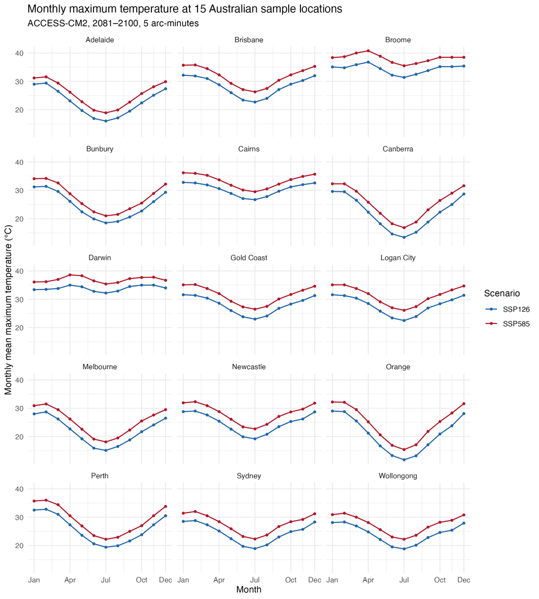

```r
seasonal_plot <- ggplot2::ggplot(city_month, ggplot2::aes(x = month_no, y = tmax_c, colour = Scenario, group = Scenario)) + # 横轴月份、纵轴温度，按情景连线
  ggplot2::geom_line(linewidth = 0.6) + # 画每个情景的季节曲线
  ggplot2::geom_point(size = 1) + # 标出每月的真实提取值
  ggplot2::facet_wrap(~ Site, ncol = 3) + # 每个城市一格，保持可比的公共纵轴
  ggplot2::scale_x_continuous(breaks = c(1, 4, 7, 10, 12), labels = month.abb[c(1, 4, 7, 10, 12)]) + # 只标部分月份避免拥挤
  ggplot2::scale_colour_manual(values = c(SSP126 = "#2166AC", SSP585 = "#B2182B")) + # 给两个情景固定颜色
  ggplot2::labs(title = "Monthly maximum temperature at 15 Australian sample locations", subtitle = "ACCESS-CM2, 2081–2100, 5 arc-minutes", x = "Month", y = "Monthly mean maximum temperature (°C)", colour = "Scenario") + # 写清变量、模型、时期和单位
  ggplot2::theme_minimal(base_size = 11) # 使用清晰的基本主题
print(seasonal_plot)
```

### 城市差值箱线图

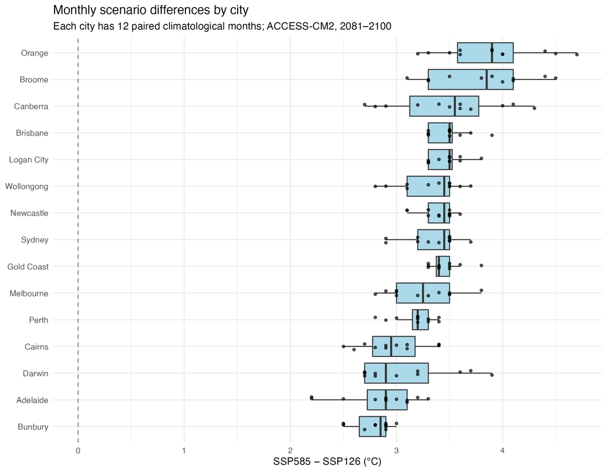

```r
box_plot <- ggplot2::ggplot(paired, ggplot2::aes(x = reorder(Site, delta_c, FUN = median), y = delta_c)) + # 按城市差值中位数排列
  ggplot2::geom_hline(yintercept = 0, linetype = "dashed", colour = "grey50") + # 以零线标明两个情景没有差异的位置
  ggplot2::geom_boxplot(fill = "#ABD9E9", outlier.shape = NA) + # 用箱体显示中位数、四分位数和须
  ggplot2::geom_jitter(width = 0.12, height = 0, size = 1.1, alpha = 0.65) + # 展示每个城市十二个月的差值，避免只见箱体
  ggplot2::coord_flip() + # 横置城市名，防止重叠
  ggplot2::labs(title = "Monthly scenario differences by city", subtitle = "Each city has 12 paired climatological months; ACCESS-CM2, 2081–2100", x = NULL, y = "SSP585 − SSP126 (°C)") + # 把差值方向写在轴上
  ggplot2::theme_minimal(base_size = 11) # 统一图表主题
print(box_plot)
```

### 城市—月份差值分布

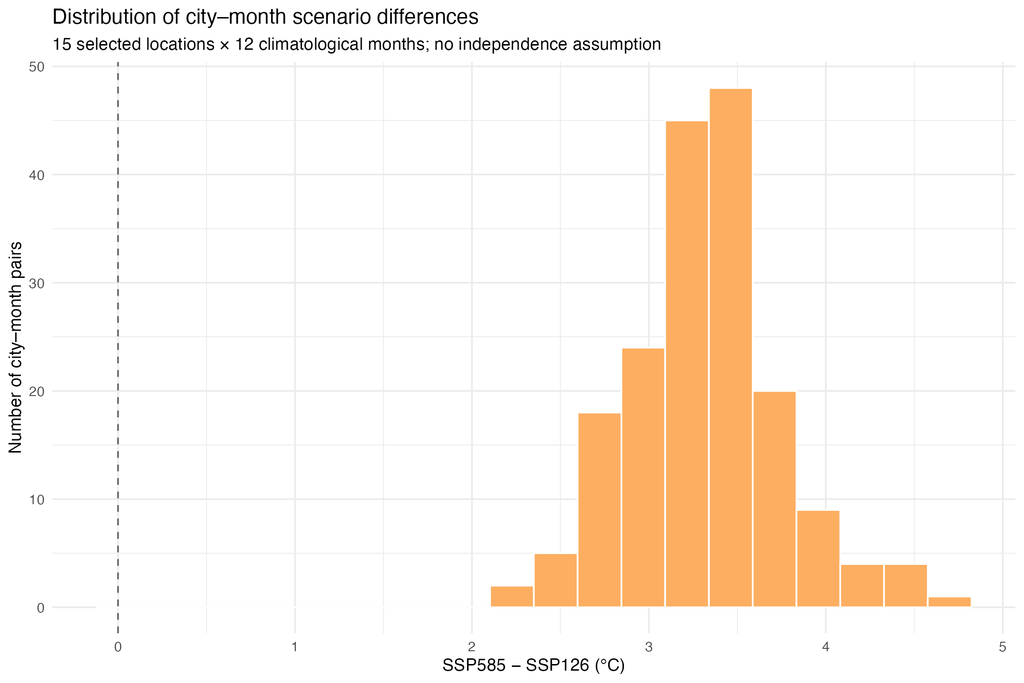

```r
hist_plot <- ggplot2::ggplot(paired, ggplot2::aes(x = delta_c)) + # 使用全部城市与月份的 180 个配对差值
  ggplot2::geom_histogram(bins = 20, fill = "#FDAE61", colour = "white") + # 将差值分成 20 个区间并数频数
  ggplot2::geom_vline(xintercept = 0, linetype = "dashed", colour = "grey40") + # 标出零差值
  ggplot2::labs(title = "Distribution of city–month scenario differences", subtitle = "15 selected locations × 12 climatological months; no independence assumption", x = "SSP585 − SSP126 (°C)", y = "Number of city–month pairs") + # 明确横轴单位与纵轴的计数对象
  ggplot2::theme_minimal(base_size = 11) # 使用相同的图表主题
print(hist_plot)
```

### 国家差值与城市点

栅格和城市点使用共同色标范围；国界仅为显示按 1000 米容差简化。地图显示投影不改变提取使用的原始网格。

```r
city_result_sf <- dplyr::left_join(city_sf, delta_stats, by = "Site", relationship = "one-to-one") # 按地点名把城市差值统计接到点几何
city_result_3112 <- sf::st_transform(city_result_sf, 3112) # 城市点转成和显示边界一致的投影
aus_display <- sf::st_simplify(aus_3112, dTolerance = 1000, preserveTopology = TRUE) # 只为显示按 1000 米容差简化，分析掩膜未使用这份简化边界
map_min <- terra::global(mean_delta_raster, fun = "min", na.rm = TRUE)[1, 1] # 获取国家差值图的最小值，用于统一图例范围
map_max <- terra::global(mean_delta_raster, fun = "max", na.rm = TRUE)[1, 1] # 获取国家差值图的最大值
map_limits <- range(c(map_min, map_max, city_result_3112$mean_delta_c)) # 国家栅格和城市点共用完整的颜色范围
tmap::tmap_mode("plot") # 使用静态地图，方便在 Plots 中查看和导出
```

```
## ℹ tmap modes "plot" - "view"
## ℹ toggle with `tmap::ttm()`
```

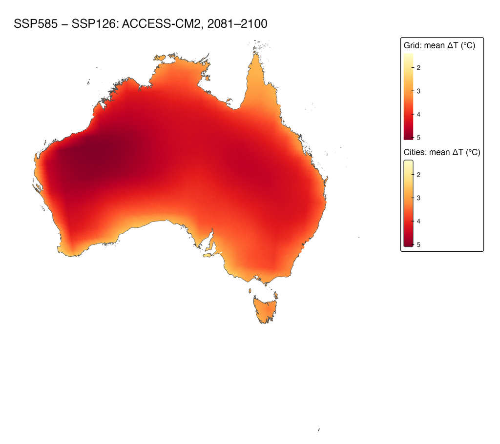

```r
result_map <- tmap::tm_shape(mean_delta_raster, crs = 3112) + # 把十二个月平均情景差作为地图底图，以澳大利亚投影显示
  tmap::tm_raster(col = "mean_delta_c", col.scale = tmap::tm_scale_continuous(values = "brewer.yl_or_rd", limits = map_limits), col.legend = tmap::tm_legend(title = "Grid: mean ΔT (°C)")) + # 用共同范围的连续色带表示像元情景差
  tmap::tm_shape(aus_display) + # 在栅格上叠加简化后的显示边界
  tmap::tm_borders(col = "grey30", lwd = 0.6) + # 画出国界，不盖住栅格
  tmap::tm_shape(city_result_3112) + # 再叠加城市采样点
  tmap::tm_dots(fill = "mean_delta_c", fill.scale = tmap::tm_scale_continuous(values = "brewer.yl_or_rd", limits = map_limits), fill.legend = tmap::tm_legend(title = "Cities: mean ΔT (°C)"), size = 0.35) + # 城市点使用相同颜色范围，避免图例各自伸缩
  tmap::tm_title("SSP585 − SSP126: ACCESS-CM2, 2081–2100") + # 标明差值方向、模型和时期
  tmap::tm_layout(frame = FALSE) # 去掉外框，让显示更简洁
print(result_map)
```

## 可选导出

每次建立新的时间戳目录，保留旧结果；CSV 记录输入、取样审计、配对值和统计，PNG 使用 ragg。`week03/outputs/` 及原始数据保持本地。

```r
stamp <- format(Sys.time(), "%Y%m%d-%H%M%S") # 用实际运行时间创建新结果目录名
output_dir <- file.path(root, "week03/outputs", paste0("homework-access-cm2-", stamp)) # 所有本次结果统一放到一个目录
if (dir.exists(output_dir)) stop("已有同名运行目录，请等一秒后重新运行或改名。") # 不覆盖同一时间戳的旧结果
dir.create(output_dir, recursive = TRUE, showWarnings = FALSE) # 创建本次输出目录
write_new_csv <- function(x, filename) { # 定义只写新文件的 CSV 保存函数
  target <- file.path(output_dir, filename) # 为本次结果拼接路径
  if (file.exists(target)) stop("不覆盖已有文件：", target) # 同名文件已存在时停止
  readr::write_csv(x, target) # 保存表格，不写多余行号
}
write_new_csv(input_record, "input-sources-and-checksums.csv") # 保存真实来源、文件名和校验记录
write_new_csv(cities, "city-coordinate-source-sample.csv") # 保存城市原坐标、更正参考坐标和来源
write_new_csv(sampling_audit, "coastal-sampling-audit.csv") # 保存共同格号、邻格使用标记和点到格中心距离
write_new_csv(paired, "paired-city-month-temperatures.csv") # 保存两个情景及逐月配对差值，供本地复查
write_new_csv(city_stats, "city-scenario-descriptive-statistics.csv") # 保存每城、每情景的描述统计
write_new_csv(delta_stats, "city-difference-descriptive-statistics.csv") # 保存每城差值的描述统计
write_new_csv(comparison, "scenario-statistic-comparison.csv") # 保存两个情景的统计并列比较
write_new_csv(month_stats, "monthly-city-sample-difference-statistics.csv") # 保存逐月城市样本统计
ggplot2::ggsave(file.path(output_dir, "seasonal-scenario-curves.png"), plot = seasonal_plot, device = ragg::agg_png, width = 10, height = 12, units = "in", dpi = 150)
ggplot2::ggsave(file.path(output_dir, "city-difference-boxplot.png"), plot = box_plot, device = ragg::agg_png, width = 9, height = 7, units = "in", dpi = 150) # 保存箱线图
ggplot2::ggsave(file.path(output_dir, "city-month-difference-histogram.png"), plot = hist_plot, device = ragg::agg_png, width = 9, height = 6, units = "in", dpi = 150) # 保存直方图
tmap::tmap_save(result_map, filename = file.path(output_dir, "australia-scenario-difference-map.png"), device = ragg::agg_png, width = 9, height = 8, units = "in", dpi = 150) # 保存 tmap 结果图，不导出完整原始气候数据
writeLines(capture.output(sessionInfo()), file.path(output_dir, "session-info.txt")) # 记录本次实际 R 与包版本
saved_files <- list.files(output_dir, full.names = TRUE) # 列出本次实际生成的文件
stopifnot(length(saved_files) == 13L, all(file.info(saved_files)$size > 0)) # 核对 8 张 CSV、4 张 PNG 和版本记录确实存在且非空
print(saved_files)
```

## 报告与使用范围

从新 R 会话 Knit 生成 HTML。安装、下载、导出三块继续保持各自 `eval=FALSE`。结果解释需对应同一输入版本和取样审计，保留单模型、有限城市点、海岸邻格近似、月气候平均与等权统计的限制。

WorldClim 和 GADM 允许学术及其他非商业使用；原始数据重新分发或商业使用需要许可。原始栅格、边界和详细提取表保留本地，发布范围按来源许可核对。

## 来源与改编

- [官方第 3 章 Homework](https://andrewmaclachlan.github.io/CASA0005repo/spatial-descriptive-statistics.html#homework-2)
- [WorldClim CMIP6 说明](https://www.worldclim.org/data/cmip6/cmip6climate.html)
- [5 分下载表](https://www.worldclim.org/data/cmip6/cmip6_clim5m.html)
- [SSP126：下载 tmax GeoTIFF](https://geodata.ucdavis.edu/cmip6/5m/ACCESS-CM2/ssp126/wc2.1_5m_tmax_ACCESS-CM2_ssp126_2081-2100.tif)
- [SSP585：下载 tmax GeoTIFF](https://geodata.ucdavis.edu/cmip6/5m/ACCESS-CM2/ssp585/wc2.1_5m_tmax_ACCESS-CM2_ssp585_2081-2100.tif)
- [GADM 澳大利亚 GeoPackage](https://geodata.ucdavis.edu/gadm/gadm4.1/gpkg/gadm41_AUS.gpkg)
- [澳大利亚气象局 Melbourne Olympic Park 086338](https://www.bom.gov.au/climate/averages/tables/cw_086338.shtml)
- [terra 官方提取说明](https://rspatial.github.io/terra/reference/extract.html)
- [GADM 国家下载](https://gadm.org/download_country.html)
- [WorldClim 许可](https://www.worldclim.org/about.html)
- [GADM 许可](https://gadm.org/license.html)

中文整理与代码适配使用 AI 辅助；原作者、许可及改编范围见来源与改编范围。